# NBA data Analysis (CS 241 Final)

## Importing the data

```python
import pandas as pd
import matplotlib
import seaborn as sns
import numpy as np
```

```python
players = pd.read_csv("nba_basketball_data/basketball_players.csv")

master = pd.read_csv("nba_basketball_data/basketball_master.csv")

data = pd.merge(players, master, how = "left", left_on = "playerID", right_on = "bioID")
```

```python
data
```

|  | playerID | year | stint | tmID | lgID | GP | GS | minutes | points | oRebounds | ... | birthDate | birthCity | birthState | birthCountry | highSchool | hsCity | hsState | hsCountry | deathDate | race |
| --- | --- | --- | --- | --- | --- | --- | --- | --- | --- | --- | --- | --- | --- | --- | --- | --- | --- | --- | --- | --- | --- |
| 0 | abramjo01 | 1946 | 1 | PIT | NBA | 47 | 0 | 0 | 527 | 0 | ... | 1919-02-09 | Etna | PA | USA | Etna | Etna | PA | USA | 2000-06-09 | W |
| 1 | aubucch01 | 1946 | 1 | DTF | NBA | 30 | 0 | 0 | 65 | 0 | ... | 1916-05-18 | Gary | IN | USA | Horace Mann | Gary | IN | USA | 2005-04-14 | W |
| 2 | bakerno01 | 1946 | 1 | CHS | NBA | 4 | 0 | 0 | 0 | 0 | ... | 1923-02-17 | Victoria | BC | CAN | NaN | NaN | NaN | NaN | 1989-04-23 | W |
| 3 | baltihe01 | 1946 | 1 | STB | NBA | 58 | 0 | 0 | 138 | 0 | ... | 1921-06-21 | (ht) New Castle | PA | USA | New Castle Senior | New Castle | PA | USA | 1968-01-01 | W |
| 4 | barrjo01 | 1946 | 1 | STB | NBA | 58 | 0 | 0 | 295 | 0 | ... | 1918-08-08 | NaN | NaN | NaN | Shamokin | Shamokin | PA | USA | 2002-07-01 | W |
| 5 | baumhfr01 | 1946 | 1 | CLR | NBA | 45 | 0 | 0 | 631 | 0 | ... | 1918-10-07 | Midvale | OH | USA | Midvale | Midvale | OH | USA | 1997-12-14 | W |
| 6 | beckemo01 | 1946 | 1 | PIT | NBA | 17 | 0 | 0 | 108 | 0 | ... | 1917-02-24 | NaN | NaN | NaN | Fifth Avenue | Pittsburgh | PA | USA | 1996-01-09 | W |
| 7 | beckemo01 | 1946 | 2 | BOS | NBA | 6 | 0 | 0 | 13 | 0 | ... | 1917-02-24 | NaN | NaN | NaN | Fifth Avenue | Pittsburgh | PA | USA | 1996-01-09 | W |
| 8 | beckemo01 | 1946 | 3 | DTF | NBA | 20 | 0 | 0 | 41 | 0 | ... | 1917-02-24 | NaN | NaN | NaN | Fifth Avenue | Pittsburgh | PA | USA | 1996-01-09 | W |
| 9 | beendha01 | 1946 | 1 | PRO | NBA | 58 | 0 | 0 | 713 | 0 | ... | 1916-06-02 | Haarlem | NaN | HOL | North Plainfield | North Plainfield | NJ | USA | 2003-10-25 | W |
| 10 | biasaha01 | 1946 | 1 | TRH | NBA | 6 | 0 | 0 | 6 | 0 | ... | 1922-01-14 | Beano | NaN | ITA | Gordon McGregor | Windsor | ON | CAN | 1996-04-20 | W |
| 11 | brighal01 | 1946 | 1 | BOS | NBA | 58 | 0 | 0 | 567 | 0 | ... | 1923-09-22 | Eureka | CA | USA | Wilson | Long Beach | CA | USA | 1992-06-10 | W |
| 12 | brindau01 | 1946 | 1 | NYK | NBA | 12 | 0 | 0 | 34 | 0 | ... | 1923-12-31 | Mineola | NY | USA | Rockville Centre | Rockville Centre | NY | USA | 1957-11-19 | W |
| 13 | brownha01 | 1946 | 1 | DTF | NBA | 54 | 0 | 0 | 264 | 0 | ... | 1923-10-02 | NaN | NaN | NaN | NaN | NaN | NaN | NaN | 0000-00-00 | W |
| 14 | brownle01 | 1946 | 1 | CLR | NBA | 5 | 0 | 0 | 0 | 0 | ... | 1919-10-12 | NaN | NaN | NaN | Cheyenne | Cheyenne | WY | USA | 1990-10-14 | W |
| 15 | byrneto01 | 1946 | 1 | NYK | NBA | 60 | 0 | 0 | 453 | 0 | ... | 1923-02-19 | New York | NY | USA | DeWitt Clinton | Bronx | NY | USA | 1981-01-09 | W |
| 16 | bytzumi01 | 1946 | 1 | PIT | NBA | 60 | 0 | 0 | 210 | 0 | ... | 1922-06-18 | NaN | NaN | NaN | Duquesne | Pittsburgh | PA | USA | 1989-01-24 | W |
| 17 | callato01 | 1946 | 1 | PRO | NBA | 13 | 0 | 0 | 17 | 0 | ... | 1921-06-02 | NaN | NaN | NaN | NaN | NaN | NaN | NaN | 1996-10-03 | W |
| 18 | calveer01 | 1946 | 1 | PRO | NBA | 59 | 0 | 0 | 845 | 0 | ... | 1924-01-30 | Pawtucket | RI | USA | East | Pawtucket | RI | USA | 2003-10-20 | W |
| 19 | carlich01 | 1946 | 1 | CHS | NBA | 51 | 0 | 0 | 256 | 0 | ... | 1916-11-02 | NaN | LA | USA | Pomona | Pomona | CA | USA | 1988-08-03 | W |
| 20 | carlsdo01 | 1946 | 1 | CHS | NBA | 59 | 0 | 0 | 630 | 0 | ... | 1919-03-22 | NaN | MN | USA | Edison | Minneapolis | MN | USA | 2004-10-16 | W |
| 21 | cluggbo01 | 1946 | 1 | NYK | NBA | 54 | 0 | 0 | 238 | 0 | ... | 1917-09-18 | Marion | KY | USA | Corbin / Williamsburgh / Catlettsburg | Corbin / Williamsburgh / Catlettsburg | KY | USA | 2008-09-05 | W |
| 22 | connoch01 | 1946 | 1 | BOS | NBA | 49 | 0 | 0 | 227 | 0 | ... | 1921-04-10 | Brooklyn | NY | USA | Erasmus Hall / Adelphi Academy | Brooklyn / Garden City | NY | USA | 1992-11-10 | W |
| 23 | corleke01 | 1946 | 1 | CLR | NBA | 3 | 0 | 0 | 0 | 0 | ... | 0000-00-00 | NaN | NaN | NaN | NaN | NaN | NaN | NaN | 0000-00-00 | W |
| 24 | crislha01 | 1946 | 1 | BOS | NBA | 4 | 0 | 0 | 6 | 0 | ... | 1923-12-31 | Richmond | CA | USA | Richmond | Richmond | CA | USA | 1987-11-02 | W |
| 25 | curear01 | 1946 | 1 | PRO | NBA | 12 | 0 | 0 | 10 | 0 | ... | 1919-08-07 | New Bedford | MA | USA | New Bedford | New Bedford | MA | USA | 2003-11-28 | W |
| 26 | dallmho01 | 1946 | 1 | PHW | NBA | 60 | 0 | 0 | 528 | 0 | ... | 1922-05-24 | San Francisco | CA | USA | Lowell | San Francisco | CA | USA | 1991-12-19 | W |
| 27 | davisau01 | 1946 | 1 | STB | NBA | 59 | 0 | 0 | 287 | 0 | ... | 1921-03-28 | NaN | NaN | NaN | East Central | Ada? | OK | USA | 1996-11-23 | W |
| 28 | davisbi01 | 1946 | 1 | CHS | NBA | 47 | 0 | 0 | 84 | 0 | ... | 1921-10-03 | NaN | NaN | NaN | NaN | NaN | NaN | NaN | 0000-00-00 | W |
| 29 | dehnehe01 | 1946 | 1 | PRO | NBA | 10 | 0 | 0 | 14 | 0 | ... | 0000-00-00 | NaN | NaN | NaN | NaN | NaN | NaN | NaN | 0000-00-00 | W |
| ... | ... | ... | ... | ... | ... | ... | ... | ... | ... | ... | ... | ... | ... | ... | ... | ... | ... | ... | ... | ... | ... |
| 23721 | lacoufr01 | 1962 | 0 | OAO | ABL1 | 25 | 0 | 901 | 494 | 0 | ... | 1938-02-07 | San Francisco | CA | USA | St. Ignatius | San Francisco | CA | USA | 1972-08-05 | B |
| 23722 | millsda01 | 1962 | 0 | OAO | ABL1 | 21 | 0 | 359 | 155 | 0 | ... | 1940-06-11 | Columbus | OH | USA | East | Columbus | NY | USA | 0000-00-00 | B |
| 23723 | romanni01 | 1962 | 0 | OAO | ABL1 | 25 | 0 | 755 | 225 | 0 | ... | 1933-12-02 | NaN | NaN | NaN | Alameda | Alameda | CA | USA | 1999-11-17 | W |
| 23724 | toddro01 | 1962 | 0 | OAO | ABL1 | 24 | 0 | 733 | 339 | 0 | ... | 1934-04-26 | Porterville | CA | USA | Mt. Whitney | Visalia | CA | USA | 0000-00-00 | W |
| 23725 | turneja02 | 1962 | 0 | OAO | ABL1 | 25 | 0 | 930 | 373 | 0 | ... | 1939-06-05 | NaN | NaN | NaN | Newport | Newport | KY | USA | 0000-00-00 | W |
| 23726 | vaughgo01 | 1962 | 0 | OAO | ABL1 | 22 | 0 | 350 | 122 | 0 | ... | 1932-03-01 | Brookesville | MS | USA | Edwardsville | Edwardsville | IL | USA | 0000-00-00 | B |
| 23727 | wilkibo01 | 1962 | 0 | OAO | ABL1 | 23 | 0 | 339 | 128 | 0 | ... | 1938-02-24 | LaPorte | IN | USA | LaPorte | LaPorte | IN | USA | 0000-00-00 | W |
| 23728 | yateswa01 | 1962 | 0 | OAO | ABL1 | 25 | 0 | 624 | 268 | 0 | ... | 1937-11-07 | Little Rock | AR | USA | North Little Rock | North Little Rock | AR | USA | 0000-00-00 | W |
| 23729 | bellwh01 | 1962 | 0 | PGR | ABL1 | 7 | 0 | 223 | 69 | 0 | ... | 1932-09-13 | Monticello | KY | USA | Warsaw | Warsaw | IN | USA | 0000-00-00 | W |
| 23730 | curtich01 | 1962 | 0 | PGR | ABL1 | 22 | 0 | 666 | 301 | 0 | ... | 1937-10-22 | NaN | NaN | NaN | Columbia | Richland | WA | USA | 2004-10-31 | W |
| 23731 | curtihe01 | 1962 | 0 | PGR | ABL1 | 20 | 0 | 596 | 275 | 0 | ... | NaN | NaN | NaN | NaN | NaN | NaN | NaN | NaN | 0000-00-00 | NaN |
| 23732 | hawkico01 | 1962 | 0 | PGR | ABL1 | 16 | 0 | 668 | 447 | 0 | ... | 1942-07-17 | Brooklyn | NY | USA | Boys | Brooklyn | NY | USA | 0000-00-00 | B |
| 23733 | kennewa01 | 1962 | 0 | PGR | ABL1 | 5 | 0 | 91 | 50 | 0 | ... | 0000-00-00 | NaN | NaN | NaN | NaN | NaN | NaN | NaN | 0000-00-00 | B |
| 23734 | manghwa01 | 1962 | 0 | PGR | ABL1 | 22 | 0 | 529 | 213 | 0 | ... | 0000-00-00 | NaN | NaN | NaN | New Castle | New Castle | PA | USA | 0000-00-00 | B |
| 23735 | mccarjo01 | 1962 | 0 | PGR | ABL1 | 18 | 0 | 420 | 95 | 0 | ... | 1934-04-25 | Buffalo | NY | USA | Bishop Timon | Buffalo | NY | USA | 0000-00-00 | W |
| 23736 | mccoyji01 | 1962 | 0 | PGR | ABL1 | 22 | 0 | 847 | 350 | 0 | ... | 0000-00-00 | NaN | NaN | NaN | Farrell | Farrell | PA | USA | 0000-00-00 | B |
| 23737 | rolliph01 | 1962 | 0 | PGR | ABL1 | 17 | 0 | 611 | 221 | 0 | ... | 1934-01-19 | Wickliffe | KY | USA | Wickliffe | Wickliffe | KY | USA | 0000-00-00 | W |
| 23738 | tyrach01 | 1962 | 0 | PGR | ABL1 | 23 | 0 | 518 | 212 | 0 | ... | 1935-08-16 | Louisville | KY | USA | Atherton | Louisville | KY | USA | 2006-12-29 | W |
| 23739 | wiesebo01 | 1962 | 0 | PGR | ABL1 | 15 | 0 | 252 | 101 | 0 | ... | 1938-12-22 | Cincinnati | OH | USA | McNicholas | Cincinnati | OH | USA | 0000-00-00 | W |
| 23740 | alixlo01 | 1962 | 0 | PHT | ABL1 | 1 | 0 | 3 | 0 | 0 | ... | 0000-00-00 | NaN | NaN | NaN | David Prouty | Spencer | MA | USA | 0000-00-00 | W |
| 23741 | blyesy01 | 1962 | 0 | PHT | ABL1 | 28 | 0 | 975 | 496 | 0 | ... | 1938-02-14 | NaN | NaN | NaN | Benjamin Franklin | New York | NY | USA | 0000-00-00 | B |
| 23742 | chmiemo01 | 1962 | 0 | PHT | ABL1 | 20 | 0 | 528 | 208 | 0 | ... | 1941-12-12 | NaN | NaN | NaN | Holy Redeemer | Detroit | MI | USA | 0000-00-00 | W |
| 23743 | clarkbo01 | 1962 | 0 | PHT | ABL1 | 16 | 0 | 217 | 59 | 0 | ... | 1939-03-21 | NaN | NaN | NaN | NaN | NaN | NaN | NaN | 0000-00-00 | W |
| 23744 | hillcl01 | 1962 | 0 | PHT | ABL1 | 22 | 0 | 422 | 145 | 0 | ... | 1938-05-24 | Newark | NJ | USA | Southside | Newark | NJ | USA | 0000-00-00 | B |
| 23745 | johnsan01 | 1962 | 0 | PHT | ABL1 | 28 | 0 | 732 | 314 | 0 | ... | 1932-11-08 | Kalamazoo | MI | USA | North Hollywood | North Hollywood | CA | USA | 2002-08-30 | B |
| 23746 | kaisero01 | 1962 | 0 | PHT | ABL1 | 27 | 0 | 978 | 467 | 0 | ... | 1938-04-07 | Dale | IN | USA | Dale | Dale | IN | USA | 0000-00-00 | W |
| 23747 | spragbr01 | 1962 | 0 | PHT | ABL1 | 27 | 0 | 746 | 356 | 0 | ... | 0000-00-00 | Williamsburg | VA | USA | Williamsburg | Williamsburg | VA | USA | 0000-00-00 | B |
| 23748 | tayloro02 | 1962 | 0 | PHT | ABL1 | 28 | 0 | 1007 | 355 | 0 | ... | 1937-01-30 | NaN | NaN | NaN | Rich | Park Forest | IL | USA | 0000-00-00 | W |
| 23749 | wellsra01 | 1962 | 0 | PHT | ABL1 | 2 | 0 | 36 | 4 | 0 | ... | 1940-09-03 | NaN | NaN | NaN | Marshall | Chicago | IL | USA | 1968-08-02 | B |
| 23750 | wrighle01 | 1962 | 0 | PHT | ABL1 | 28 | 0 | 813 | 195 | 0 | ... | 1938-05-06 | New York | NY | USA | Aycock | Rockdale | TX | USA | 0000-00-00 | B |

23751 rows × 68 columns

## Columns

```python
data.columns
```

```
Index(['playerID', 'year', 'stint', 'tmID', 'lgID', 'GP', 'GS', 'minutes',
       'points', 'oRebounds', 'dRebounds', 'rebounds', 'assists', 'steals',
       'blocks', 'turnovers', 'PF', 'fgAttempted', 'fgMade', 'ftAttempted',
       'ftMade', 'threeAttempted', 'threeMade', 'PostGP', 'PostGS',
       'PostMinutes', 'PostPoints', 'PostoRebounds', 'PostdRebounds',
       'PostRebounds', 'PostAssists', 'PostSteals', 'PostBlocks',
       'PostTurnovers', 'PostPF', 'PostfgAttempted', 'PostfgMade',
       'PostftAttempted', 'PostftMade', 'PostthreeAttempted', 'PostthreeMade',
       'note', 'bioID', 'useFirst', 'firstName', 'middleName', 'lastName',
       'nameGiven', 'fullGivenName', 'nameSuffix', 'nameNick', 'pos',
       'firstseason', 'lastseason', 'height', 'weight', 'college',
       'collegeOther', 'birthDate', 'birthCity', 'birthState', 'birthCountry',
       'highSchool', 'hsCity', 'hsState', 'hsCountry', 'deathDate', 'race'],
      dtype='object')
```

## PART I - SPECIFIC ASSIGNMENTS

1. Calculate the mean and median number of points scored. (In other words, each row is the amount of points a player scored during a particular season. Calculate the median of these values. The result of this is that we have the median number of points players score each season.)

```python
points_mean = data.points.mean()

print("The mean number of points scored: {:.2f}".format(points_mean))
```

```
The mean number of points scored: 492.13
```

```python
points_median = data.points.median()

print("The median number of points scored: {:.2f}".format(points_mean))
```

[output not shown]

1. Determine the highest number of points recorded in a single season. Identify who scored those points and the year they did so.

```python
highest_points = data.points.max()

print("The highest number of points: {}".format(highest_points))
```

```
The highest number of points: 4029
```

```python
highest_points_year = data[data.points == highest_points][["points","year","firstName","middleName","lastName","nameSuffix"]]

print("The year of highest number of points: \n {}".format(highest_points_year))
```

```
The year of highest number of points:
       points  year firstName middleName     lastName nameSuffix
2078    4029  1961    Wilton     Norman  Chamberlain        NaN
```

1. Produce a boxplot that shows the distribution of total points, total assists, and total rebounds (each of these three is a separate box plot, but they can be on the same scale and in the same graphic).

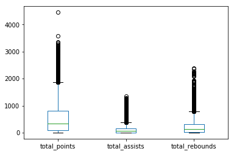

```python
data["total_points"] = data.points + data.PostPoints
data["total_assists"] = data.assists + data.PostAssists
data["total_rebounds"] = data.rebounds + data.PostRebounds



data[["total_points","total_assists","total_rebounds"]].plot(kind = "box")

matplotlib.pyplot.show()
```

1. Produce a plot that shows how the number of points scored has changed over time by showing the median of points scored per year, over time. The x-axis is the year and the yaxis is the median number of points among all players for that year.

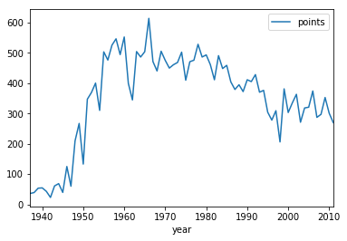

```python
year_points = data[["year","points"]].groupby("year").median()
year_points.plot(kind ="line")
matplotlib.pyplot.show()
```

## PART II - COME UP WITH SUPPORTING EVIDENCE

1. Some players score a lot of points because they attempt a lot of shots. Among players that have scored a lot of points, are there some that are much more efficient (points per attempt) than others?

Here is the list of top 10 players who are have higher points per attempt than the other players.

```python
data["PointsPerAttempt"] = data.points / (data.fgAttempted + data.ftAttempted)

player_points_attempted = data[["playerID","PointsPerAttempt"]].groupby("playerID").mean()
player_points_attempted = player_points_attempted[player_points_attempted.PointsPerAttempt != np.inf]
```

```python
top10_points_player = player_points_attempted.nlargest(10,"PointsPerAttempt")["PointsPerAttempt"]
```

```python
top10_points_player
```

```
playerID
rosenno01    11.222222
skardbo01    10.000000
johnsha02     7.666667
lambeha01     7.666667
napolpa01     7.380952
bishora01     7.333333
headga01      7.000000
juntupa01     6.342105
goffja01      6.220779
shannfr01     6.200000
Name: PointsPerAttempt, dtype: float64
```

```python
top10_points_player_t = pd.merge(top10_points_player, master, how = "left", left_on = "playerID", right_on = "bioID")[["firstName","middleName","lastName","nameSuffix","PointsPerAttempt"]]
top10_points_player_t
```

|  | firstName | middleName | lastName | nameSuffix | PointsPerAttempt |
| --- | --- | --- | --- | --- | --- |
| 0 | Norm | NaN | Rosen | NaN | 11.222222 |
| 1 | Robert | J. | Skarda | NaN | 10.000000 |
| 2 | Harry | NaN | Johnson | NaN | 7.666667 |
| 3 | Harold | NaN | Lambert | NaN | 7.666667 |
| 4 | Paul | Wally | Napolitano | NaN | 7.380952 |
| 5 | Ralph | English | Bishop | NaN | 7.333333 |
| 6 | Garland | M. | Head | NaN | 7.000000 |
| 7 | Paul | NaN | Juntunen | NaN | 6.342105 |
| 8 | James | NaN | Goff | NaN | 6.220779 |
| 9 | Frank | E. | Shannon | NaN | 6.200000 |

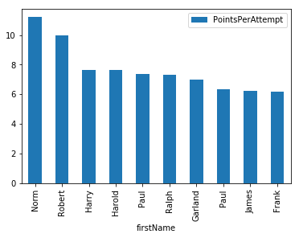

```python
top10_points_player_t[["firstName","PointsPerAttempt"]].set_index("firstName").plot(kind = "bar")
matplotlib.pyplot.show()
```

1. It seems like some players may excel in one statistical category, but produce very little in other areas. Are there any players that are exceptional across many categories?

```python
statistical_category = ["points","rebounds","assists","steals","blocks","turnovers"]
exceptional_player = data[statistical_category + ["playerID"]].groupby("playerID").mean().nlargest(10, statistical_category)

for i in statistical_category:
    exceptional_player[i+ "Rank"] = exceptional_player[i].rank(ascending = True, pct =  True)

exceptional_player = exceptional_player[exceptional_player.columns[-6:]].reset_index()
exceptional_player
```

|  | playerID | pointsRank | reboundsRank | assistsRank | stealsRank | blocksRank | turnoversRank |
| --- | --- | --- | --- | --- | --- | --- | --- |
| 0 | jordami01 | 1.0 | 0.2 | 0.8 | 1.00 | 0.50 | 0.5 |
| 1 | jamesle01 | 0.9 | 0.4 | 0.9 | 0.80 | 0.70 | 1.0 |
| 2 | chambwi01 | 0.8 | 1.0 | 0.5 | 0.15 | 0.15 | 0.2 |
| 3 | duranke01 | 0.7 | 0.3 | 0.1 | 0.50 | 0.80 | 0.8 |
| 4 | malonka01 | 0.6 | 0.7 | 0.3 | 0.70 | 0.60 | 0.7 |
| 5 | abdulka01 | 0.5 | 0.8 | 0.4 | 0.40 | 1.00 | 0.4 |
| 6 | roberos01 | 0.4 | 0.5 | 1.0 | 0.30 | 0.30 | 0.2 |
| 7 | pettibo01 | 0.3 | 0.9 | 0.2 | 0.15 | 0.15 | 0.2 |
| 8 | ervinju01 | 0.2 | 0.6 | 0.6 | 0.90 | 0.90 | 0.9 |
| 9 | bryanko01 | 0.1 | 0.1 | 0.7 | 0.60 | 0.40 | 0.6 |

```python
pd.merge(exceptional_player, master, how = "left", left_on = "playerID", right_on = "bioID")[["firstName","middleName","lastName","nameSuffix"]].set_index(exceptional_player.playerID)
```

| playerID | firstName | middleName | lastName | nameSuffix |
| --- | --- | --- | --- | --- |
| jordami01 | Michael | Jeffrey | Jordan | NaN |
| jamesle01 | LeBron | Raymone | James | NaN |
| chambwi01 | Wilton | Norman | Chamberlain | NaN |
| duranke01 | Kevin | Wayne | Durant | NaN |
| malonka01 | Karl | Anthony | Malone | NaN |
| abdulka01 | Kareem | NaN | Abdul-Jabbar | NaN |
| roberos01 | Oscar | Palmer | Robertson | NaN |
| pettibo01 | Robert | E. Lee | Pettit | Jr. |
| ervinju01 | Julius | Winfield | Erving | II |
| bryanko01 | Kobe | Bean | Bryant | NaN |

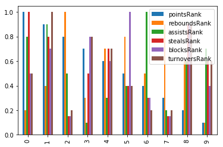

```python
exceptional_player.plot(kind = "bar")
matplotlib.pyplot.show()
```

1. Much has been said about the rise of the three-point shot in recent years. It seems that players are shooting and making more three-point shots than ever. Recognizing that this dataset doesn't contain the very most recent data, do you see a trend of more three-point shots either across the league or among certain groups of players? Is there a point at which popularity increased dramatically?

```python
data["total_threeAttempted"] = data.threeAttempted + data.PostthreeAttempted
data["total_threeMade"] = data.threeMade + data.PostthreeMade

three_data_per_year = data.groupby(["lgID","year"]).mean().reset_index()[["lgID","year","total_threeAttempted","total_threeMade"]]
three_data_per_year = three_data_per_year[(three_data_per_year.total_threeAttempted > 0) & (three_data_per_year.total_threeMade > 0)]
three_data_per_year = three_data_per_year.melt(["lgID","year"])

three_data_per_year
```

|  | lgID | year | variable | value |
| --- | --- | --- | --- | --- |
| 0 | ABA | 1967 | total_threeAttempted | 26.702857 |
| 1 | ABA | 1968 | total_threeAttempted | 29.897849 |
| 2 | ABA | 1969 | total_threeAttempted | 35.516304 |
| 3 | ABA | 1970 | total_threeAttempted | 32.994186 |
| 4 | ABA | 1971 | total_threeAttempted | 27.754286 |
| 5 | ABA | 1972 | total_threeAttempted | 21.351351 |
| 6 | ABA | 1973 | total_threeAttempted | 23.413333 |
| 7 | ABA | 1974 | total_threeAttempted | 22.686131 |
| 8 | ABA | 1975 | total_threeAttempted | 17.610294 |
| 9 | ABL1 | 1961 | total_threeAttempted | 34.542857 |
| 10 | ABL1 | 1962 | total_threeAttempted | 21.323077 |
| 11 | NBA | 1979 | total_threeAttempted | 16.578947 |
| 12 | NBA | 1980 | total_threeAttempted | 12.101796 |
| 13 | NBA | 1981 | total_threeAttempted | 13.066474 |
| 14 | NBA | 1982 | total_threeAttempted | 12.614085 |
| 15 | NBA | 1983 | total_threeAttempted | 15.350610 |
| 16 | NBA | 1984 | total_threeAttempted | 18.950292 |
| 17 | NBA | 1985 | total_threeAttempted | 19.451977 |
| 18 | NBA | 1986 | total_threeAttempted | 27.145658 |
| 19 | NBA | 1987 | total_threeAttempted | 27.215789 |
| 20 | NBA | 1988 | total_threeAttempted | 36.949495 |
| 21 | NBA | 1989 | total_threeAttempted | 37.477435 |
| 22 | NBA | 1990 | total_threeAttempted | 40.908434 |
| 23 | NBA | 1991 | total_threeAttempted | 42.600000 |
| 24 | NBA | 1992 | total_threeAttempted | 50.589074 |
| 25 | NBA | 1993 | total_threeAttempted | 53.650901 |
| 26 | NBA | 1994 | total_threeAttempted | 84.827907 |
| 27 | NBA | 1995 | total_threeAttempted | 82.903885 |
| 28 | NBA | 1996 | total_threeAttempted | 83.587084 |
| 29 | NBA | 1997 | total_threeAttempted | 65.078788 |
| ... | ... | ... | ... | ... |
| 58 | NBA | 1982 | total_threeMade | 3.011268 |
| 59 | NBA | 1983 | total_threeMade | 3.881098 |
| 60 | NBA | 1984 | total_threeMade | 5.336257 |
| 61 | NBA | 1985 | total_threeMade | 5.545198 |
| 62 | NBA | 1986 | total_threeMade | 8.196078 |
| 63 | NBA | 1987 | total_threeMade | 8.600000 |
| 64 | NBA | 1988 | total_threeMade | 11.891414 |
| 65 | NBA | 1989 | total_threeMade | 12.349169 |
| 66 | NBA | 1990 | total_threeMade | 13.086747 |
| 67 | NBA | 1991 | total_threeMade | 14.103529 |
| 68 | NBA | 1992 | total_threeMade | 17.078385 |
| 69 | NBA | 1993 | total_threeMade | 17.912162 |
| 70 | NBA | 1994 | total_threeMade | 30.516279 |
| 71 | NBA | 1995 | total_threeMade | 30.347648 |
| 72 | NBA | 1996 | total_threeMade | 30.029354 |
| 73 | NBA | 1997 | total_threeMade | 22.490909 |
| 74 | NBA | 1998 | total_threeMade | 14.858650 |
| 75 | NBA | 1999 | total_threeMade | 26.256410 |
| 76 | NBA | 2000 | total_threeMade | 25.051020 |
| 77 | NBA | 2001 | total_threeMade | 28.074468 |
| 78 | NBA | 2002 | total_threeMade | 29.096491 |
| 79 | NBA | 2003 | total_threeMade | 25.439072 |
| 80 | NBA | 2004 | total_threeMade | 28.152091 |
| 81 | NBA | 2005 | total_threeMade | 29.603516 |
| 82 | NBA | 2006 | total_threeMade | 32.726899 |
| 83 | NBA | 2007 | total_threeMade | 32.690702 |
| 84 | NBA | 2008 | total_threeMade | 34.124031 |
| 85 | NBA | 2009 | total_threeMade | 33.029297 |
| 86 | NBA | 2010 | total_threeMade | 31.207721 |
| 87 | NBA | 2011 | total_threeMade | 26.589147 |

88 rows × 4 columns

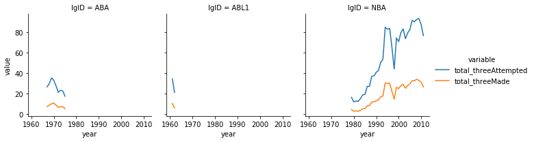

```python
grid = sns.FacetGrid(three_data_per_year, col = "lgID", hue= "variable")
grid.map(sns.lineplot, "year", "value").add_legend()
matplotlib.pyplot.show()
```

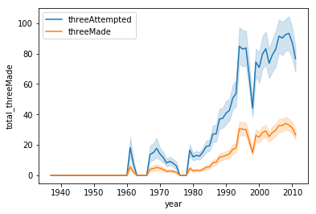

```python
plot = sns.lineplot(x = "year", y = "total_threeAttempted", data = data)
plot2 = sns.lineplot(x = "year", y = "total_threeMade", data = data)

matplotlib.pyplot.legend(['threeAttempted','threeMade'])
matplotlib.pyplot.show()
```

## PART III - SHOW CREATIVITY

1. Many sports analysts argue about which player is the GOAT (the Greatest Of All Time). Based on this data, who would you say is the GOAT? Provide evidence to back up your decision.

I generated GOAT Score which calculates each rank of points, rebounds, assists, steals, blocks, and turnovers for players on percentage format and add them up by allotting a proportion of 50 % to points, and giving 10 % to rest of stats. And here is the list of top 10 players who can be referred as GOAT.

```python
stats = ["points","rebounds","assists","steals","blocks","turnovers"]
player_stat = data[["playerID"] + stats].groupby("playerID").mean()

for i in stats:
    player_stat[i+ "Rank"] = player_stat[i].rank(ascending = True, pct =  True)
```

```python
player_stat_rank = player_stat.iloc[:,[i for i in range(-6,0)]]
player_stat_rank
```

| playerID | pointsRank | reboundsRank | assistsRank | stealsRank | blocksRank | turnoversRank |
| --- | --- | --- | --- | --- | --- | --- |
| abdelal01 | 0.563736 | 0.650622 | 0.396696 | 0.629411 | 0.764532 | 0.686111 |
| abdulka01 | 0.998980 | 0.997553 | 0.966347 | 0.921681 | 0.997756 | 0.947175 |
| abdulma01 | 0.919029 | 0.776055 | 0.976545 | 0.507037 | 0.491740 | 0.200082 |
| abdulma02 | 0.942280 | 0.650214 | 0.945748 | 0.909239 | 0.672445 | 0.915664 |
| abdulta01 | 0.583112 | 0.602794 | 0.557822 | 0.747094 | 0.768815 | 0.699164 |
| abdulza01 | 0.715888 | 0.906792 | 0.643484 | 0.634204 | 0.839690 | 0.417703 |
| abdursh01 | 0.970426 | 0.960024 | 0.895778 | 0.936977 | 0.953702 | 0.980216 |
| abernto01 | 0.649398 | 0.734448 | 0.697532 | 0.803080 | 0.764532 | 0.612380 |
| ablefo01 | 0.012951 | 0.233734 | 0.212727 | 0.224352 | 0.237100 | 0.200082 |
| abramjo01 | 0.528350 | 0.114216 | 0.363859 | 0.224352 | 0.237100 | 0.200082 |
| ackeral01 | 0.213951 | 0.309912 | 0.306955 | 0.495819 | 0.535794 | 0.457373 |
| ackerdo01 | 0.267591 | 0.344177 | 0.488476 | 0.224352 | 0.237100 | 0.200082 |
| acresma01 | 0.542729 | 0.806649 | 0.508464 | 0.715072 | 0.815725 | 0.678768 |
| actonbu01 | 0.359678 | 0.482052 | 0.383337 | 0.224352 | 0.237100 | 0.200082 |
| adamsal01 | 0.959821 | 0.969814 | 0.972670 | 0.985927 | 0.967163 | 0.983276 |
| adamsdo01 | 0.745564 | 0.848256 | 0.778707 | 0.801142 | 0.688558 | 0.502142 |
| adamsge01 | 0.824597 | 0.871915 | 0.809300 | 0.794004 | 0.859372 | 0.894554 |
| adamsha01 | 0.392515 | 0.465123 | 0.332755 | 0.615643 | 0.585560 | 0.552621 |
| adamsja01 | 0.830308 | 0.817153 | 0.750663 | 0.224352 | 0.237100 | 0.200082 |
| adamsmi01 | 0.928207 | 0.743422 | 0.987967 | 0.984907 | 0.699164 | 0.949113 |
| adamsne01 | 0.110035 | 0.114216 | 0.096574 | 0.224352 | 0.237100 | 0.200082 |
| adamsra01 | 0.311442 | 0.114216 | 0.096574 | 0.224352 | 0.237100 | 0.200082 |
| adamssp01 | 0.324699 | 0.114216 | 0.096574 | 0.224352 | 0.237100 | 0.200082 |
| adamswi01 | 0.309300 | 0.114216 | 0.096574 | 0.224352 | 0.237100 | 0.200082 |
| addisra01 | 0.704059 | 0.666633 | 0.670610 | 0.760963 | 0.806853 | 0.735060 |
| adelmri01 | 0.728228 | 0.657965 | 0.911891 | 0.646543 | 0.515195 | 0.200082 |
| adrieje01 | 0.255252 | 0.458393 | 0.309300 | 0.495819 | 0.623802 | 0.480828 |
| afflaar01 | 0.860901 | 0.775342 | 0.820110 | 0.824699 | 0.854579 | 0.792576 |
| agerma01 | 0.237406 | 0.307975 | 0.274628 | 0.477667 | 0.532225 | 0.482562 |
| aguirma01 | 0.984703 | 0.898633 | 0.928717 | 0.890271 | 0.869876 | 0.980420 |
| ... | ... | ... | ... | ... | ... | ... |
| youngda01 | 0.593514 | 0.527432 | 0.883949 | 0.879054 | 0.619825 | 0.720375 |
| younger01 | 0.138181 | 0.114216 | 0.096574 | 0.224352 | 0.237100 | 0.200082 |
| youngje01 | 0.502346 | 0.114216 | 0.096574 | 0.224352 | 0.237100 | 0.200082 |
| youngko01 | 0.138181 | 0.267285 | 0.212727 | 0.224352 | 0.237100 | 0.410667 |
| youngmi01 | 0.353049 | 0.412910 | 0.348052 | 0.607383 | 0.515195 | 0.475525 |
| youngni01 | 0.880379 | 0.633898 | 0.669386 | 0.807567 | 0.784724 | 0.822252 |
| youngpe01 | 0.090455 | 0.267285 | 0.272078 | 0.508158 | 0.486437 | 0.429023 |
| youngsa01 | 0.668978 | 0.634102 | 0.564756 | 0.797267 | 0.792168 | 0.719355 |
| youngth01 | 0.933306 | 0.916480 | 0.747909 | 0.968795 | 0.879971 | 0.883337 |
| youngti01 | 0.299103 | 0.437181 | 0.299918 | 0.495819 | 0.515195 | 0.523455 |
| youngwi01 | 0.012951 | 0.114216 | 0.096574 | 0.224352 | 0.237100 | 0.200082 |
| youriab01 | 0.012951 | 0.114216 | 0.096574 | 0.224352 | 0.237100 | 0.200082 |
| yuesu01 | 0.085764 | 0.114216 | 0.240669 | 0.466857 | 0.515195 | 0.447073 |
| zadelst01 | 0.341424 | 0.114216 | 0.096574 | 0.224352 | 0.237100 | 0.200082 |
| zagarro01 | 0.777483 | 0.607281 | 0.803896 | 0.224352 | 0.237100 | 0.200082 |
| zasloma01 | 0.848868 | 0.511829 | 0.744340 | 0.224352 | 0.237100 | 0.200082 |
| zawolze01 | 0.733632 | 0.828370 | 0.727514 | 0.224352 | 0.237100 | 0.200082 |
| zelleda01 | 0.387314 | 0.402713 | 0.677442 | 0.224352 | 0.237100 | 0.200082 |
| zellega01 | 0.401897 | 0.434224 | 0.402917 | 0.224352 | 0.237100 | 0.447073 |
| zelleha01 | 0.701611 | 0.114216 | 0.540281 | 0.224352 | 0.237100 | 0.200082 |
| zenoto01 | 0.144707 | 0.338976 | 0.212727 | 0.535692 | 0.606975 | 0.523455 |
| zeravji01 | 0.076790 | 0.114216 | 0.096574 | 0.224352 | 0.237100 | 0.200082 |
| zevenph01 | 0.226698 | 0.333469 | 0.261269 | 0.517234 | 0.515195 | 0.462472 |
| zhizhwa01 | 0.410259 | 0.451866 | 0.325209 | 0.541097 | 0.689068 | 0.540587 |
| zidekge01 | 0.388130 | 0.508974 | 0.323883 | 0.510504 | 0.582297 | 0.558740 |
| ziegeba01 | 0.191006 | 0.114216 | 0.096574 | 0.224352 | 0.237100 | 0.200082 |
| zimmede01 | 0.064144 | 0.267285 | 0.332755 | 0.224352 | 0.237100 | 0.462472 |
| zoetji01 | 0.040995 | 0.298899 | 0.212727 | 0.466857 | 0.606975 | 0.462472 |
| zopfbi01 | 0.438201 | 0.478585 | 0.730063 | 0.224352 | 0.237100 | 0.200082 |
| zunicma01 | 0.653987 | 0.114216 | 0.503263 | 0.224352 | 0.237100 | 0.200082 |

4903 rows × 6 columns

```python
player_stat_rank_goat = player_stat_rank * [0.5, 0.1, 0.1, 0.1, 0.1, 0.1]
player_stat_rank_goat["GOAT_score"] = player_stat_rank_goat.sum(axis = 1)
top_10_goat = player_stat_rank_goat.nlargest(10,"GOAT_score")
```

```python
top_10_goat
```

| playerID | pointsRank | reboundsRank | assistsRank | stealsRank | blocksRank | turnoversRank | GOAT_score |
| --- | --- | --- | --- | --- | --- | --- | --- |
| ervinju01 | 0.499184 | 0.098776 | 0.097675 | 0.099776 | 0.099470 | 0.099878 | 0.994758 |
| jamesle01 | 0.499898 | 0.097267 | 0.099694 | 0.099592 | 0.096941 | 0.099918 | 0.993310 |
| birdla01 | 0.498368 | 0.098960 | 0.099327 | 0.099429 | 0.096329 | 0.099633 | 0.992046 |
| malonka01 | 0.499592 | 0.099511 | 0.096370 | 0.099205 | 0.096533 | 0.099776 | 0.990985 |
| jordami01 | 0.500000 | 0.095064 | 0.098695 | 0.099939 | 0.096472 | 0.099266 | 0.989435 |
| garneke01 | 0.495105 | 0.099470 | 0.096879 | 0.098470 | 0.099286 | 0.098511 | 0.987722 |
| barklch01 | 0.496737 | 0.099490 | 0.096043 | 0.098929 | 0.096145 | 0.099551 | 0.986896 |
| olajuha01 | 0.497043 | 0.099286 | 0.090271 | 0.099449 | 0.099980 | 0.099429 | 0.985458 |
| duranke01 | 0.499694 | 0.096370 | 0.093596 | 0.098062 | 0.097767 | 0.099796 | 0.985285 |
| wadedw01 | 0.498164 | 0.090455 | 0.099062 | 0.099368 | 0.097226 | 0.099735 | 0.984010 |

```python
top_10_goat = pd.merge(top_10_goat["GOAT_score"],master, how = "inner", left_on = "playerID", right_on = "bioID")[["firstName","middleName","lastName","nameSuffix","GOAT_score"]]
top_10_goat
```

|  | firstName | middleName | lastName | nameSuffix | GOAT_score |
| --- | --- | --- | --- | --- | --- |
| 0 | Julius | Winfield | Erving | II | 0.994758 |
| 1 | LeBron | Raymone | James | NaN | 0.993310 |
| 2 | Larry | Joe | Bird | NaN | 0.992046 |
| 3 | Karl | Anthony | Malone | NaN | 0.990985 |
| 4 | Michael | Jeffrey | Jordan | NaN | 0.989435 |
| 5 | Kevin | Maurice | Garnett | NaN | 0.987722 |
| 6 | Charles | Wade | Barkley | NaN | 0.986896 |
| 7 | Hakeem | Abdul | Olajuwon | NaN | 0.985458 |
| 8 | Kevin | Wayne | Durant | NaN | 0.985285 |
| 9 | Dwyane | Tyrone | Wade | NaN | 0.984010 |

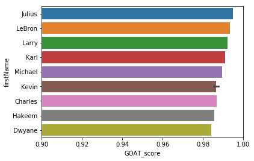

```python
sns.barplot(x = "GOAT_score", y = "firstName", data = top_10_goat)
matplotlib.pyplot.xlim(0.9, 1)
matplotlib.pyplot.show()
```

1. The biographical data in this dataset contains information about home towns, home states, and home countries for these players. Can you find anything interesting about players who came from a similar location?

```python
master.columns
```

```
Index(['bioID', 'useFirst', 'firstName', 'middleName', 'lastName', 'nameGiven',
       'fullGivenName', 'nameSuffix', 'nameNick', 'pos', 'firstseason',
       'lastseason', 'height', 'weight', 'college', 'collegeOther',
       'birthDate', 'birthCity', 'birthState', 'birthCountry', 'highSchool',
       'hsCity', 'hsState', 'hsCountry', 'deathDate', 'race'],
      dtype='object')
```

```python
location_group_height = master.groupby(["birthState"]).mean()["height"].sort_values(ascending = False).nlargest(10)
location_group_weight = master.groupby(["birthState"]).mean()["weight"].sort_values(ascending = False).nlargest(10)
```

```python
pd.DataFrame(location_group_height)
```

| birthState | height |
| --- | --- |
| MAN | 84.000000 |
| NH | 82.000000 |
| NSW | 82.000000 |
| FK | 81.000000 |
| (Fr Guiana) | 81.000000 |
| ME | 81.000000 |
| ON | 79.875000 |
| QU | 79.800000 |
| MT | 79.142857 |
| HI | 79.000000 |

```python
pd.DataFrame(location_group_weight)
```

| birthState | weight |
| --- | --- |
| NSW | 280.000000 |
| (Fr Guiana) | 275.000000 |
| MAN | 255.000000 |
| NH | 240.000000 |
| ME | 230.000000 |
| ON | 222.625000 |
| QU | 222.000000 |
| PR | 220.000000 |
| MN | 215.306122 |
| IA | 215.208333 |

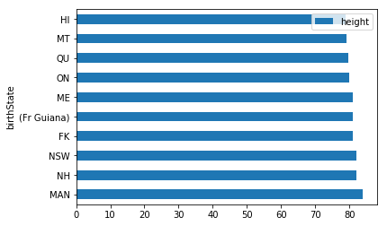

```python
location_group_height.plot(kind = 'barh', x = "birthState", y = "height")
matplotlib.pyplot.legend(["height"])
matplotlib.pyplot.show()
```

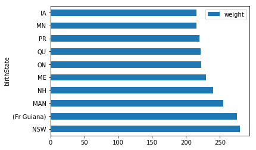

```python
location_group_weight.plot(kind = 'barh', x = "birthState", y = "weight")
matplotlib.pyplot.legend(["weight"])
matplotlib.pyplot.show()
```

1. Find something else in this dataset that you consider interesting. Produce a graph to communicate your insight.

#### 1. The correlation between weight and height per position

```python
data_r = data[["pos","height","weight"]].replace([np.inf, -np.inf], np.nan).dropna()
data_r
```

|  | pos | height | weight |
| --- | --- | --- | --- |
| 0 | F | 75.0 | 195.0 |
| 1 | G | 70.0 | 137.0 |
| 2 | G | 72.0 | 180.0 |
| 3 | F | 76.0 | 195.0 |
| 4 | F | 75.0 | 205.0 |
| 5 | G | 70.0 | 170.0 |
| 6 | G-F | 73.0 | 185.0 |
| 7 | G-F | 73.0 | 185.0 |
| 8 | G-F | 73.0 | 185.0 |
| 9 | C-F | 77.5 | 185.0 |
| 10 | G | 71.0 | 175.0 |
| 11 | F | 74.0 | 195.0 |
| 12 | F | 76.0 | 175.0 |
| 13 | G | 72.0 | 155.0 |
| 14 | F | 75.0 | 190.0 |
| 15 | F-G | 75.0 | 175.0 |
| 16 | F | 73.0 | 170.0 |
| 17 | G | 73.0 | 180.0 |
| 18 | G | 70.0 | 145.0 |
| 19 | F-C | 77.0 | 195.0 |
| 20 | G-F | 72.0 | 170.0 |
| 21 | C | 80.0 | 235.0 |
| 22 | F-C | 77.0 | 190.0 |
| 23 | C | 76.5 | 210.0 |
| 24 | F | 75.0 | 215.0 |
| 25 | F | 72.0 | 198.0 |
| 26 | F | 76.0 | 200.0 |
| 27 | G-F | 74.0 | 175.0 |
| 28 | F | 75.0 | 215.0 |
| 29 | F | 74.5 | 175.0 |
| ... | ... | ... | ... |
| 23718 | G | 75.0 | 170.0 |
| 23719 | G | 68.0 | 163.0 |
| 23720 | C-F | 82.0 | 235.0 |
| 23721 | G-F | 77.0 | 195.0 |
| 23722 | F | 78.0 | 210.0 |
| 23723 | C-F | 79.0 | 210.0 |
| 23724 | G | 75.0 | 185.0 |
| 23725 | G-F | 77.0 | 200.0 |
| 23726 | F-G | 76.0 | 180.0 |
| 23727 | G | 73.0 | 180.0 |
| 23728 | C | 80.0 | 230.0 |
| 23729 | G | 72.0 | 174.0 |
| 23730 | F | 79.0 | 200.0 |
| 23732 | F-C | 80.0 | 201.0 |
| 23734 | F | 75.0 | 205.0 |
| 23735 | G | 73.0 | 185.0 |
| 23737 | G | 74.0 | 185.0 |
| 23738 | C-F | 80.0 | 230.0 |
| 23739 | F | 76.0 | 215.0 |
| 23740 | C | 81.0 | 210.0 |
| 23741 | F | 77.0 | 235.0 |
| 23742 | C | 81.0 | 235.0 |
| 23743 | F | 81.0 | 200.0 |
| 23744 | G | 73.0 | 185.0 |
| 23745 | F-G | 77.0 | 215.0 |
| 23746 | G | 72.5 | 190.0 |
| 23747 | F | 77.0 | 188.0 |
| 23748 | G | 72.0 | 175.0 |
| 23749 | G | 73.0 | 180.0 |
| 23750 | F | 81.0 | 215.0 |

23712 rows × 3 columns

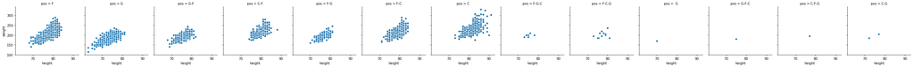

```python
grid = sns.FacetGrid(data_r[data_r.height > 0][data_r.weight > 0], col = "pos")
grid.map(sns.scatterplot, "height", "weight")
matplotlib.pyplot.show()
```

#### 2. How much height have been changed over years per position

```python
data_r2 = data[["pos","year","height","weight"]].replace([np.inf, -np.inf], np.nan).dropna()[data.height > 0][data.weight > 0]
data_r2
```

|  | pos | year | height | weight |
| --- | --- | --- | --- | --- |
| 0 | F | 1946 | 75.0 | 195.0 |
| 1 | G | 1946 | 70.0 | 137.0 |
| 2 | G | 1946 | 72.0 | 180.0 |
| 3 | F | 1946 | 76.0 | 195.0 |
| 4 | F | 1946 | 75.0 | 205.0 |
| 5 | G | 1946 | 70.0 | 170.0 |
| 6 | G-F | 1946 | 73.0 | 185.0 |
| 7 | G-F | 1946 | 73.0 | 185.0 |
| 8 | G-F | 1946 | 73.0 | 185.0 |
| 9 | C-F | 1946 | 77.5 | 185.0 |
| 10 | G | 1946 | 71.0 | 175.0 |
| 11 | F | 1946 | 74.0 | 195.0 |
| 12 | F | 1946 | 76.0 | 175.0 |
| 13 | G | 1946 | 72.0 | 155.0 |
| 14 | F | 1946 | 75.0 | 190.0 |
| 15 | F-G | 1946 | 75.0 | 175.0 |
| 16 | F | 1946 | 73.0 | 170.0 |
| 17 | G | 1946 | 73.0 | 180.0 |
| 18 | G | 1946 | 70.0 | 145.0 |
| 19 | F-C | 1946 | 77.0 | 195.0 |
| 20 | G-F | 1946 | 72.0 | 170.0 |
| 21 | C | 1946 | 80.0 | 235.0 |
| 22 | F-C | 1946 | 77.0 | 190.0 |
| 23 | C | 1946 | 76.5 | 210.0 |
| 24 | F | 1946 | 75.0 | 215.0 |
| 25 | F | 1946 | 72.0 | 198.0 |
| 26 | F | 1946 | 76.0 | 200.0 |
| 27 | G-F | 1946 | 74.0 | 175.0 |
| 28 | F | 1946 | 75.0 | 215.0 |
| 29 | F | 1946 | 74.5 | 175.0 |
| ... | ... | ... | ... | ... |
| 23718 | G | 1962 | 75.0 | 170.0 |
| 23719 | G | 1962 | 68.0 | 163.0 |
| 23720 | C-F | 1962 | 82.0 | 235.0 |
| 23721 | G-F | 1962 | 77.0 | 195.0 |
| 23722 | F | 1962 | 78.0 | 210.0 |
| 23723 | C-F | 1962 | 79.0 | 210.0 |
| 23724 | G | 1962 | 75.0 | 185.0 |
| 23725 | G-F | 1962 | 77.0 | 200.0 |
| 23726 | F-G | 1962 | 76.0 | 180.0 |
| 23727 | G | 1962 | 73.0 | 180.0 |
| 23728 | C | 1962 | 80.0 | 230.0 |
| 23729 | G | 1962 | 72.0 | 174.0 |
| 23730 | F | 1962 | 79.0 | 200.0 |
| 23732 | F-C | 1962 | 80.0 | 201.0 |
| 23734 | F | 1962 | 75.0 | 205.0 |
| 23735 | G | 1962 | 73.0 | 185.0 |
| 23737 | G | 1962 | 74.0 | 185.0 |
| 23738 | C-F | 1962 | 80.0 | 230.0 |
| 23739 | F | 1962 | 76.0 | 215.0 |
| 23740 | C | 1962 | 81.0 | 210.0 |
| 23741 | F | 1962 | 77.0 | 235.0 |
| 23742 | C | 1962 | 81.0 | 235.0 |
| 23743 | F | 1962 | 81.0 | 200.0 |
| 23744 | G | 1962 | 73.0 | 185.0 |
| 23745 | F-G | 1962 | 77.0 | 215.0 |
| 23746 | G | 1962 | 72.5 | 190.0 |
| 23747 | F | 1962 | 77.0 | 188.0 |
| 23748 | G | 1962 | 72.0 | 175.0 |
| 23749 | G | 1962 | 73.0 | 180.0 |
| 23750 | F | 1962 | 81.0 | 215.0 |

23602 rows × 4 columns

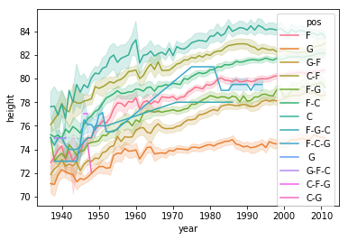

```python
sns.lineplot(x = "year", y = "height", data = data_r2, hue = "pos")
matplotlib.pyplot.show()
```